# DGLMExtPois: Advances in Dealing with Over and Under-dispersion in a Double GLM Framework

```r
plot(CustomerProfile$ncust, hp1$gamma,
     xlab = expression(ncust[i]),
     ylab = expression(gamma[i]),
     pch = 19
)
abline(h = 1, lty = "dashed", col = "blue")
```

[output not shown]

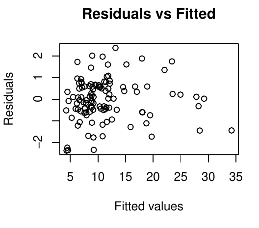

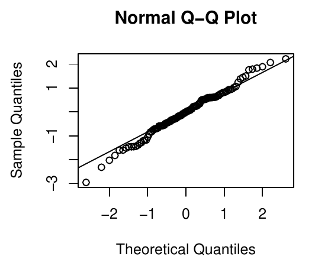

1. Residuals versus fitted values.
2. Normal QQ plot.

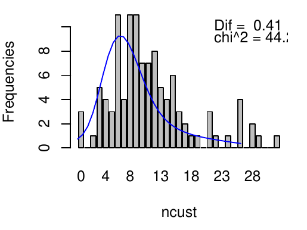

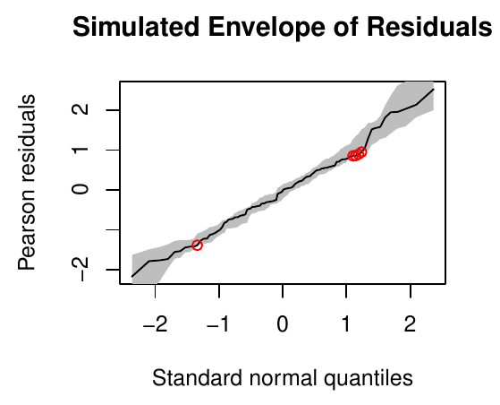

3. Bar_plot for the observed marginal frequencies. The blue line represents the expected marginal frequencies for the response variable.
4. Normal QQ plot with simulated envelopes of residuals. The shaded gray region contains 95% of the simulated points for each observation.

Figure 2: Regression diagnostics. The plots do not show evidence against the adequacy of the model.

```r
par(mfrow = c(2, 2))
set.seed(21)
plot(hp1) # Residuals against fitted values and normal QQ plot

# Observed and expected marginal frequencies
expec_hp <- hP_expected(hp1)
barplot(expec_hp$observed_freq[0:33], xlab = "ncust", ylab = "Frequencies")
lines(expec_hp$frequencies[1:33], x = c(0:32), col = "blue")
text(x = c(25, 25), y = c(10, 9), c(paste("Dif = ", round(expec_hp$dif, 2)),
     paste(expression(chi ^ 2), "=", round(expec_hp$chi2, 2))), pos = 4)

# Envelope
r1 <- residuals(hp1, envelope = TRUE)
envelope_down <- apply(r1$sim_residuals, 1, min)
envelope_up <- apply(r1$sim_residuals, 1, max)
weirds <- which(r1$residuals < envelope_down | r1$residuals > envelope_up)
score_weirds <- qnorm(weirds / 111)
points(score_weirds, r1$residuals[weirds], col = "red")
```

## Performance comparison

In this section eight datasets, previously used in different works, have been used to compare the performance of fitting $hP_{\mu, \gamma}$ and $CMP_{\mu, \nu}$ models with the *DGLMExtPois* package (version 0.2.1, with *nloptr* version 2.0.0), $CMP_{\theta, \nu}$ models with the *COMPoissonReg* package (version 0.7.0) and $CMP_{\mu, \nu}$ models with the *mpcmp* package (version 0.3.6). We think that the selected datasets cover a wide range of examples, with low, medium and large sample sizes, and under- and over-dispersion in their variability structure.

For each dataset we have tried to fit $hP_{\mu, \gamma}$, $CMP_{\mu, \nu}$ and $CMP_{\theta, \nu}$ models, and we have computed some goodness of fit criteria (Lord, Geedipally, and Guikema 2010), such as AIC, mean prediction bias (MPB), mean absolute deviance (MAD), mean squared predictive error (MSPE) and the Pearson statistic. Additionally, we have calculated the time needed to fit the models with these R packages. The experimentation has been carried out on a computer equipped with an Intel Core i7 processor (3.20GHz) and 64 GB of RAM. Table 4 shows the AICs and the computational times obtained by the different models for the different datasets. The first column of the table lists the names of the datasets and the second column lists the number of observations of each dataset. The best AICs results are highlighted in bold. Unfortunately, the *COMPoissonReg* and *mpcmp* packages crash with some datasets, which is indicated by a dash in the table. In relation to the crashes, we clarify that all the fits have been carried out with the default optional arguments. To obtain a better approximation of the execution time needed to estimate a model, we have estimated each model 10 times and computed the average time required for the estimate. These average times are presented in Table 4 as follows. A value of 1.0 means the model has the fastest average estimate time and this fastest average time, in seconds, is shown in the last column. A value of, e.g., 41.4 means the average estimate time of the model is 41.4 times larger than the average of the fastest. Table 5 shows the results of the $hP_{\mu, \gamma}$ and $CMP_{\mu, \nu}$ models, fitted with the *DGLMExtPois* package, according to other goodness of fit criteria.

Table 4: Comparison of models based on AIC (the smallest value is highlighted in bold) and relative average estimate time. For the estimate times a value of 1.0 means the model is the fastest on average for the dataset. A value of, e.g., 41.4 means the average estimate time of the model is 41.4 times larger than the average of the fastest. The fastest time is expressed in seconds. The symbol – means that the model could not be estimated.

|  |  | AIC |  |  |  | average estimate time |  |  |  |  |
| --- | --- | --- | --- | --- | --- | --- | --- | --- | --- | --- |
| Dataset | obs. | $hP_{\mu, \gamma}$ | $CMP_{\mu, \nu}$ | $CMP_{\theta, \nu}$ | *mpcmp* | $hP_{\mu, \gamma}$ | $CMP_{\mu, \nu}$ | $CMP_{\theta, \nu}$ | *mpcmp* | fastest |
| Takeover bids | 126 | 355.1 | **354.8** | – | 357.8 | 1.0 | 41.4 | – | 4.9 | 0.7 |
| Days absent | 314 | 1739.2 | **1736.1** | – | – | 1.0 | 5.1 | – | – | 23.6 |
| Cotton bolls | 125 | 555.1 | **446.3** | 466.4 | 447.2 | 1.0 | 53.4 | 10.0 | 11.5 | 0.7 |
| Korea | 162 | 218.2 | **214.5** | – | – | 1.0 | 6.0 | – | – | 2.5 |
| Toronto | 868 | 5088.4 | **5067.4** | – | 5069.4 | 17.6 | 27.6 | – | 1.0 | 9.0 |
| Insurance | 64 | 407.8 | 399.0 | 469.4 | **394.2** | 1.8 | 1.7 | 1.0 | 7.4 | 6.7 |
| Credit card | 1319 | **2392.9** | – | – | – | 1.0 | – | – | – | 1591.1 |
| Children | 1761 | 5380.4 | **5372.4** | 5393.2 | 5374.4 | 512.5 | 583.5 | 4.6 | 1.0 | 6.3 |

Table 5: Comparison of models based on additional goodness of fit criteria. MPB: mean prediction bias; MAD: mean absolute deviance; MSPE: mean squared predictive error and Pearson statistic. The best results are highlighted in bold.

[output not shown]

Next, the datasets used in the comparison are described, together with some comments about the fits for the different models:

- **Takeover bids**. The response variable is the number of bids received by 126 US firms that were successful targets of tender offers between 1978–1985. We consider 9 explanatory variables on the defensive actions taken by the management of the target firm, firm-specific characteristics and the intervention taken for both the mean and the dispersion parameter with a log-linear link. See Saez-Castillo and Conde-Sanchez (2013) for more details about these explanatory variables and other references where the dataset was analyzed. For this dataset the *COMPoissonReg* package crashes with the $CMP_{\theta, \nu}$ model. The lowest AIC is obtained by the $CMP_{\mu, \nu}$ model. The main difference between the fits of $hP_{\mu, \gamma}$ and $CMP_{\mu, \nu}$ is that the former identifies 108 out of 126 of the cases as being under-dispersed, whereas the latter identifies only 88. In general, the goodness of fit measures are quite similar, being somewhat smaller for the $hP_{\mu, \gamma}$ model. In addition, the $CMP_{\mu, \nu}$ model obtained with the *DGLMExtPois* package is slower, but with a lower AIC, than the one obtained with the *mpcmp* package.
- **Days absent**. The sample refers to 314 students sampled from two urban high schools. The response variable is the number of days absent from high school, and the explanatory variables for both the mean and the dispersion parameter are gender, math’s score (standardized score out of 100) and academic program (General, Academic and Vocational). The dataset has been analyzed, among others, by Alan Huang (2017). The *COMPoissonReg* package crashes again with the $CMP_{\theta, \nu}$ model, as does the *mpcmp* package with the $CMP_{\mu, \nu}$ model. $CMP_{\mu, \nu}$ achieves a slightly better AIC than $hP_{\mu, \gamma}$, but again requires more computational time and the goodness of fit measures are quite similar. In relation to the dispersion structure, both models identify all the cases as being over-dispersed.
- **Cotton bolls**. Here, the response variable is the number of bolls produced by 125 cotton plants. The explanatory variables, again for both the mean and the dispersion parameter, are the growth stage (vegetative, flower-bud, blossom, fig and cotton boll), and the defoliation level (with 5 levels). The model also includes the square of the defoliation level. It reproduces the analysis carried out by Zeviani et al. (2014). This is one of the cases where *COMPoissonReg* provides a $CMP_{\theta, \nu}$ fit, although the one provided by the $CMP_{\mu, \nu}$ model obtains a lower AIC (very similar to both the *DLGMExtPois* and *mpcmp* packages). Here $hP_{\mu, \gamma}$ performs worse and obtains a higher AIC. Another interesting point in relation to the $CMP_{\mu, \nu}$ fit is that, regardless of the strong under-dispersion of the complete dataset, the introduction of covariates in the dispersion parameter allows us to identify 5 cases that are actually described with over-dispersed distributions. Note also that $hP_{\mu, \gamma}$ is the fastest approach.
- **Korea crashes**. The dataset contains crash count data, which is the response variable, collected at 162 railway-highway crossings in Korea. The explanatory variables include the average daily vehicle traffic (in logarithmic scale) and 7 characteristics of the crossing. See, for example, Khazraee et al. (2015) for more details. For this dataset both the *COMPoissonReg* and *mpcmp* packages crash. The $CMP_{\mu, \nu}$ fit obtains the best AIC, although the rest of the goodness of fit measures are quite similar to those provided by the $hP_{\mu, \gamma}$ fit. Once the effect of the covariates is taken into account, both fits detect over 50 cases with under-dispersed underlying distributions.
- **Toronto crashes**. The dataset provides Toronto intersection crash data. The response variable is the number of crashes at 868 intersections, and the explanatory variables for the mean and the dispersion parameter are the average annual daily traffic in the major and minor approaches to the intersection. These data have been widely used as an example of over-dispersed crash data. See, for example, Khazraee et al. (2015). Whereas *COMPoissonReg* once again leads to a crash in the fit of a $CMP_{\theta, \nu}$ model, $CMP_{\mu, \nu}$ and $hP_{\mu, \gamma}$ provide similar fits in terms of goodness of fit measures. The $CMP_{\mu, \nu}$ model obtained with the *DGLMExtPois* package has a slightly lower AIC than the model obtained with the *mpcmp* package. In this case, the *mpcmp* package is the fastest estimating the model. There are 2 under-dispersed cases for the $hP_{\mu, \gamma}$ fit.
- **Insurance claims**. Data consist of the numbers of policyholders of an insurance company who were exposed to risk, and the number of car insurance claims made by those policyholders in the third quarter of 1973. The response variable is the number of claims, with the number of policyholders being an offset for the mean. Apart from this offset, there are 3 explanatory variables for the mean and the dispersion parameter: district of residence of the policyholder, car group and an ordered factor with the age of the insured in 4 groups. The $CMP_{\mu, \nu}$ model of the *mpcmp* package obtains the best AIC, but it is the slowest in terms of computational time. On this occasion the *COMPoissonReg* package does not fail and is the fastest, however its AIC is clearly the highest among the estimated models. Most of the cases show under-dispersion (52 and 44 for $hP_{\mu, \gamma}$ and $CMP_{\mu, \nu}$ respectively).
- **Credit card reports**. The response variable is the number of major derogatory reports. Three explanatory variables are considered: age in years plus twelfths of a year, yearly income (in USD 10,000) and average monthly credit card expenditure. For this dataset the only model that can be estimated is $hP_{\mu, \gamma}$. This is a case of over-dispersed data, but as a result of introducing covariates in the dispersion parameter, 5 under-dispersed cases appear in the $hP_{\mu, \gamma}$ model. In any case a negative binomial model fits better due to the strong over-dispersion of data.
- **Children**. In this dataset the response variable is the number of children a woman has. The explanatory variables are: age of the woman in years, years of education, nationality of the woman (German or not), belief in God (with 6 categories) and attended university (yes or no). This is an example of equidispersed data (Tutz 2011), although our models detected under-dispersion (1164 and 1238 cases for $hP_{\mu, \gamma}$ and $CMP_{\mu, \nu}$ respectively). In this case the *mpcmp* package provides a very fast $CMP_{\mu, \nu}$ fit, but with a slightly higher AIC.

In summary, the $hP_{\mu, \gamma}$ model is the only one that can provide fits for all the datasets. Regarding the AIC, the $CMP_{\mu, \nu}$ model seems to be better than the $hP_{\mu, \gamma}$ model, although the latter usually requires less estimation time. As for the comparison of the $CMP_{\mu, \nu}$ model in the *DGLMExtPois* and *mpcmp* packages, the $CMP_{\mu, \nu}$ model of the *mpcmp* package fails in more datasets and provides better results in terms of AIC for only one dataset.

## Simulation

In order to assess the performance of the estimates and standard errors in finite samples of the $hP_{\mu, \gamma}$ model a simulation has been performed. The simulation process consists of the following steps:

1. 500 values of two covariates $X$ and $Z$ are generated from a uniform distribution on the interval $(0,1)$.
2. The mean and $\gamma$ are obtained as $\mu_i = \exp\{ \beta_0 + \beta_1 x_{i} \}$ and $\gamma_i = \exp\{ \delta_0 + \delta_1 z_{i} \}$, $i=1,\dots,500$, for several values of the regression coefficients $\beta_0,\beta_1,\delta_0$ and $\delta_1$.
3. The $\lambda$ parameter is obtained as solution of @ref(eq:link) by means of the base R `optimize` function.
4. Each value of $Y$ in the sample is randomly generated using the `rhP` function.
5. Once the dataset $(Y, X, Z)$ is available, the coefficients of the $hP_{\mu, \gamma}$ model are estimated.

This process was repeated 1000 times and the average of the estimates and standard errors, as well as the standard deviation of the estimates, were calculated. The standard deviation of the estimates allows us to check whether the standard errors have been calculated correctly, while the average of the estimates allows us to determine whether there is a bias in the estimation of the coefficients. The results obtained for different values of the coefficients are shown in Table 6.

Table 6: Simulation process for $hP_{\mu, \gamma}$ models. For each combination of coefficients the mean and standard deviation (sd) of the estimates were calculated, as well as the mean of the standard errors (s.e.).

|  | $\beta_0$ |  |  | $\beta_1$ |  |  |
| --- | --- | --- | --- | --- | --- | --- |
| Coefficients | mean | sd | s.e. | mean | sd | s.e. |
| Comb. I: $\boldsymbol{\beta} = (1,0.5)$ | 0.998 | 0.0504 | 0.0507 | 0.501 | 0.0827 | 0.0829 |
| Comb. II: $\boldsymbol{\beta} = (1,0.5)$ | 0.998 | 0.0552 | 0.0555 | 0.501 | 0.0902 | 0.0904 |
| Comb. III: $\boldsymbol{\beta} = (1,0.5)$ | 0.998 | 0.0490 | 0.0492 | 0.501 | 0.0805 | 0.0805 |
|  | $\delta_0$ |  |  | $\delta_1$ |  |  |
| Coefficients | mean | sd | s.e. | mean | sd | s.e. |
| Comb. I: $\boldsymbol{\delta} = (0.5,-1)$ | 0.461 | 0.4237 | 0.4232 | -1.041 | 0.8408 | 0.8164 |
| Comb. II: $\boldsymbol{\delta} = (0.5,0.25)$ | 0.456 | 0.3834 | 0.3839 | 0.273 | 0.6625 | 0.6567 |
| Comb. III: $\boldsymbol{\delta} = (0,-0.5)$ | -0.058 | 0.4943 | 0.4866 | -0.531 | 0.9329 | 0.8980 |

The first combination of coefficients ($\boldsymbol{\beta} = (1,0.5)$ and $\boldsymbol{\delta} = (0.5,-1)$) allows for under- and over-dispersion situations. The coefficients in the second combination ($\boldsymbol{\beta} = (1,0.5)$ and $\boldsymbol{\delta} = (0.5, 0.25)$) determine a model with over-dispersion only. And finally, the third combination of coefficients ($\boldsymbol{\beta} = (1,0.5)$ and $\boldsymbol{\delta} = (0, -0.5)$) corresponds to an under-dispersed model. It can be seen that the estimates of the $\boldsymbol{\beta}$ coefficients are practically unbiased and very precise, while those of the $\boldsymbol{\delta}$ coefficients are more biased and much less precise. In any case the mean standard errors are very close to the standard deviations of the 1000 estimates, so the calculation of these standard errors seem to be correct.

A similar simulation has been performed for the $CMP_{\mu, \nu}$ model in the *DGLMExtPois* package, and the results are shown in Table 7. It can be seen that, although the estimates of the $\boldsymbol{\delta}$ coefficients are still less precise than those of the $\boldsymbol{\beta}$ coefficients, these estimates are less biased and more precise than those of the $hP_{\mu, \gamma}$ model. In this sense, the $CMP_{\mu, \nu}$ model leads to better estimates than the hyper-Poisson model.

Table 7: Simulation for $CMP_{\mu, \nu}$ models. For each combination of coefficients the mean and standard deviation (sd) of the estimates were calculated, as well as the mean of the standard errors (s.e.).

|  | $\beta_0$ |  |  | $\beta_1$ |  |  |
| --- | --- | --- | --- | --- | --- | --- |
| Coefficients | mean | sd | s.e. | mean | sd | s.e. |
| Comb. I: $\boldsymbol{\beta} = (1,0.5)$ | 0.998 | 0.0497 | 0.0498 | 0.502 | 0.0818 | 0.0812 |
| Comb. II: $\boldsymbol{\beta} = (1,0.5)$ | 0.999 | 0.0383 | 0.0386 | 0.501 | 0.0626 | 0.0627 |
| Comb. III: $\boldsymbol{\beta} = (1,0.5)$ | 0.998 | 0.0557 | 0.0556 | 0.502 | 0.0909 | 0.0911 |
|  | $\delta_0$ |  |  | $\delta_1$ |  |  |
| Coefficients | mean | sd | s.e. | mean | sd | s.e. |
| Comb. I: $\boldsymbol{\delta} = (0.5,-1)$ | 0.515 | 0.1415 | 0.1415 | -1.0132 | 0.2640 | 0.2641 |
| Comb. II: $\boldsymbol{\delta} = (0.5,0.25)$ | 0.513 | 0.1349 | 0.1343 | 0.2426 | 0.2362 | 0.2319 |
| Comb. III: $\boldsymbol{\delta} = (0,-0.5)$ | 0.012 | 0.1526 | 0.1539 | -0.5085 | 0.2807 | 0.2800 |

## The optimization process

As previously mentioned, the estimation of $hP_{\mu, \gamma}$ and $CMP_{\mu, \nu}$ models in the *DGLMExtPois* package was performed using the SLSQP optimizer included in the *nloptr* package. Because the SLSQP algorithm uses dense-matrix methods, it requires $O(m^2)$ storage and $O(m^3)$ time in $m$ dimensions (where $m$ is the number of estimated parameters, i.e., the number of observations plus the number of model coefficients), which makes it less practical for optimizing more than a few thousand parameters. Table 8 shows the datasets from the above performance comparison sorted by the dimension of the objective function when fitting an $hP_{\mu, \gamma}$ model. Also, the average estimation time for 10 estimations and the number of iterations taken by the optimizer are listed. Clearly, the dimension of the objective function has the greatest impact on optimization time, while the number of iterations plays a less important role.

Table 8: Optimization process for $hP_{\mu, \gamma}$ models. For each dataset, the dimension of the objective function, the average optimization time (in seconds) and the number of iterations are shown.

| Dataset | dimension | average time | iterations |
| --- | --- | --- | --- |
| Insurance | 84 | 12.0 | 987 |
| Takeover bids | 146 | 0.7 | 78 |
| Cotton bolls | 155 | 0.7 | 96 |
| Korea | 180 | 2.5 | 283 |
| Days absent | 324 | 23.6 | 558 |
| Toronto | 874 | 158.8 | 111 |
| Credit card | 1327 | 1591.1 | 135 |
| Children | 1781 | 3221.0 | 61 |

The `nloptr` optimization function from the *nloptr* package was used to fit the models. This function allows several termination conditions for the optimization process, of which the *DGLMExtPois* package uses, by default, the following:

- A maximum number of iterations of 1000 and,
- a fractional tolerance (`xtol_rel`) is used in the parameters $x$, so that the optimizer stops when $|\Delta x_i|/|x_i| < xtol\_rel$, with a default value for `xtol_rel` of 0.01.

Information on the optimization process can be obtained through the component `nloptr`, of class `"nloptr"`, included in the S3 object returned by the `glm.hP` function:

```r
library(mpcmp)
formula <- daysabs ~ gender + math + prog
fit <- glm.hP(formula, formula, data = attendance)
fit$nloptr$message # termination condition
[1] "NLOPT_XTOL_REACHED: Optimization stopped because xtol_rel or xtol_abs (above) was
reached."
fit$nloptr$iterations # number of iterations
[1] 558
```

The user can modify the termination conditions. For example, in the following code the second call to `glm.hP` removes the termination condition on fractional tolerance used in the parameters and set the maximum number of iterations:

```r
fit1 <- glm.hP(formula, formula, data = attendance) # default termination conditions
AIC(fit1)
[1] 1739.192
fit1$nloptr$iterations
[1] 558
fit2 <- glm.hP(formula, formula, data = attendance,
               opts = list(xtol_rel = -1, maxeval = 250))
AIC(fit2)
[1] 1739.369
fit2$nloptr$iterations
[1] 250
```

Another interesting termination condition is an approximate maximum optimization time, expressed in seconds:

```r
fit3 <- glm.hP(formula, formula, data = attendance,
               opts = list(xtol_rel = -1, maxeval = -1, maxtime = 5))
AIC(fit3)
[1] 1741.672
fit3$nloptr$iterations
[1] 124
```

The user can also see how the optimization process evolves:

```r
fit4 <- glm.hP(formula, formula, data = attendance,
               opts = list(xtol_rel = -1, maxeval = 5, print_level = 1))
iteration: 1
    f(x) = 1550.509229
iteration: 2
    f(x) = -0.000000
iteration: 3
    f(x) = 33443.986687
iteration: 4
    f(x) = 2980.009033
iteration: 5
    f(x) = 1444.775141
```

# Conclusion

In this paper we have presented *DGLMExtPois*, the only package on CRAN that allows fitting count data using the hyper-Poisson model. This model is able to fit data with over- or under-dispersion, or both for different levels of covariates. Additionally, *DGLMExtPois* can also fit COM-Poisson models, considering covariates in the mean and the dispersion parameter. The *mpcmp* package also presents this feature, so the results obtained by both packages can be compared. We have found that the *mpcmp* package fails to fit some datasets and the fits obtained are, in general, somewhat worse than those obtained with the *DGLMExtPois* package. The *COMPoissonReg* package allows covariates in the location parameter, but it models a location parameter instead of the mean. In addition, this latter package fails to fit many of the datasets used in the experimentation.

The two models implemented by the *DGLMExtPois* package achieved similar results in the experimentation, with the COM-Poisson model obtaining, in general, slightly lower AICs and needing more computational time to fit the models. We have also verified, by means of a simulation, that the COM-Poisson model is more accurate in estimating the coefficients of the covariates included in the dispersion parameter. But, overall, it cannot be said that one model is clearly better than the other. Thus, two competitive models are available to deal with count data. As shown in the example, the possibility of including covariates in the dispersion parameter is suitable for situations where there may be both over- and under-dispersion for different levels of the covariates, which makes these models especially attractive compared to those where the dispersion is constant. In fact, in the example with a constant dispersion parameter, equidispersion was obtained, whereas if covariates are considered in the dispersion parameter over- or under-dispersion can be found.

It should also be noted that the algorithm used to estimate the parameters of the hyper-Poisson model is much faster than the previous algorithms (Alan Huang 2017; Saez-Castillo and Conde-Sanchez 2013).

# Acknowledgment

We would like to thank the reviewers; their comments helped improve and clarify this manuscript and the package. In memory of our friend Antonio José, this work would not have been possible without your talent and enthusiasm.

Funding: This work was supported by MCIN/AEI/10.13039/501100011033
$$project PID2019-107793GB-I00$$
.

# Appendix

## Preliminaries

Firstly, given that
$$_{1}F_{1}\left(1,
\gamma; \lambda \right) = \sum_{y = 0}^{\infty}
\frac{\lambda^{y}}{\left(\gamma\right)_{y}},$$
it is verified that
$$\frac{\partial}{\partial \lambda} \,
_{1}F_{1}\left(1, \gamma; \lambda \right) = \sum_{y=0}^{\infty} \frac{y
\lambda^{y-1}}{\left(\gamma\right)_{y}} = \frac{1}{\lambda}
\sum_{y=0}^{\infty} y \frac{\lambda^{y}}{\left(\gamma\right)_{y}} = \,
_{1}F_{1}\left(1, \gamma; \lambda \right) \frac{\mu}{\lambda}$$
and therefore
$$\label{der1f1lambda}
\frac{\partial}{\partial \lambda} \log \left(_{1}F_{1}\left(1,
\gamma; \lambda \right) \right) = \frac{1}{_{1}F_{1}\left(1, \gamma;
\lambda \right)} \frac{\partial}{\partial \lambda} \, _{1}F_{1}\left(1,
\gamma; \lambda \right) =
\frac{\mu}{\lambda}. (\#eq:der1f1lambda)$$

Furthermore, since
$$\label{derpochgamma}
\begin{split}
\frac{\partial \left(\gamma\right)_{y}}{\partial \gamma} = &
\frac{\partial}{\partial \gamma}
\frac{\Gamma\left(\gamma+y\right)}{\Gamma\left(\gamma\right)} =
\frac{\Gamma\left(\gamma+y\right) \psi\left(\gamma+y\right)
\Gamma\left(\gamma\right) - \Gamma\left(\gamma+y\right)
\Gamma\left(\gamma\right)
\psi\left(\gamma\right)}{\Gamma\left(\gamma\right)^2} \\
= &
\frac{\Gamma\left(\gamma+y\right)}{\Gamma\left(\gamma\right)}
\left(\psi\left(\gamma+y\right)- \psi\left(\gamma\right) \right)
= \left(\gamma\right)_{y} \left(\psi\left(\gamma+y\right)-
\psi\left(\gamma\right) \right),
\end{split} (\#eq:derpochgamma)$$
where we have used
$$\frac{\partial
\Gamma\left(\gamma\right)}{\partial \gamma} = \Gamma\left(\gamma\right)
\psi\left(\gamma\right).$$

Thus, you get that
$$\begin{aligned}
\frac{\partial}{\partial \gamma} \, _{1}F_{1}\left(1, \gamma;
\lambda \right) = & \sum_{y=0}^{\infty} \frac{y \lambda^{y-1}
\frac{\partial \lambda}{\partial \gamma} \left(\gamma\right)_{y} -
\lambda^y \frac{\partial \left(\gamma\right)_{y}}{\partial
\gamma}}{\left(\gamma\right)_{y}^2} = \frac{1}{\lambda} \frac{\partial
\lambda}{\partial \gamma} \sum_{y=0}^{\infty} y
\frac{\lambda^{y}}{\left(\gamma\right)_{y}} - \sum_{y=0}^{\infty}
\frac{\lambda^y}{\left(\gamma\right)_{y}}
\left(\psi\left(\gamma+y\right)- \psi\left(\gamma\right) \right) \\
= & _{1}F_{1}\left(1, \gamma; \lambda \right) \left\{
\frac{\mu}{\lambda} \frac{\partial \lambda}{\partial \gamma} - E \left[
\psi\left(\gamma+Y\right) \right] + \psi\left(\gamma\right) \right\},
\end{aligned}$$
so
$$\label{der1f1gamma}
%\begin{split}
\frac{\partial}{\partial \gamma} \log \left(_{1}F_{1}\left(1,
\gamma; \lambda \right) \right) = \frac{1}{_{1}F_{1}\left(1, \gamma;
\lambda \right)} \frac{\partial}{\partial \gamma} \, _{1}F_{1}\left(1,
\gamma; \lambda \right) =
\frac{\mu}{\lambda} \frac{\partial \lambda}{\partial \gamma} - E
\left[ \psi\left(\gamma+Y\right) \right] + \psi\left(\gamma\right).
%\end{split} (\#eq:der1f1gamma)$$

## Proof of result 1

Using the chain rule:
$$\frac{\partial
l_{hP}}{\partial \boldsymbol{\beta}} = \frac{\partial l_{hP}}{\partial
\mu_i} \frac{\partial \mu_i}{\partial \boldsymbol{\beta}},$$
so that the score function for $\mu_i$ is:
$$\frac{\partial l_{hP}}{\partial \mu_i}
= \frac{\partial l_{hP}}{\partial \lambda_i} \frac{\partial
\lambda_i}{\partial \mu_i}.$$

Let us start with the first of the previous derivatives:
$$\label{scorelambda}
\frac{\partial l_{hP}}{\partial \lambda_i} = \sum_{i=1}^n \left\{
\frac{Y_i}{\lambda_i} - \frac{\partial}{\partial \lambda_i} \log
\left(_{1}F_{1}\left(1, \gamma_i; \lambda_i \right) \right) \right\} =
\sum_{i=1}^n \frac{Y_i -
\mu_i}{\lambda_i}, (\#eq:scorelambda)$$
where the result @ref(eq:der1f1lambda) has been used.

The second of the above derivatives is obtained using implicit differentiation, taking into account that $\lambda(\mu_i, \gamma_i)$ is solution of equation @ref(eq:link). Thus,
$$0=\sum_{y=0}^{\infty} \left(y-\mu\right)
\frac{\lambda^{y}}{\left(\gamma\right)_{y}},$$
wherein subscript $i$ has been omitted, and by differentiating with respect to $\mu$
$$\begin{aligned}
0 = & - \sum_{y=0}^{\infty}
\frac{\lambda^{y}}{\left(\gamma\right)_{y}} + \sum_{y=0}^{\infty}
\left(y-\mu\right) y \frac{\lambda^{y-1}}{\left(\gamma\right)_{y}}
\frac{\partial \lambda}{\partial \mu} = - \, _{1}F_{1}\left(1, \gamma;
\lambda \right) + \frac{1}{\lambda} \left[ \sum_{y=0}^{\infty}
\left(y-\mu\right) y \frac{\lambda^{y}}{\left(\gamma\right)_{y}} \right]
\frac{\partial \lambda}{\partial \mu} \\
= & - \, _{1}F_{1}\left(1, \gamma; \lambda \right) +
\frac{1}{\lambda} \left[ \sum_{y=0}^{\infty} \left(y-\mu\right)^2
\frac{\lambda^{y}}{\left(\gamma\right)_{y}} \right] \frac{\partial
\lambda}{\partial \mu} = - \, _{1}F_{1}\left(1, \gamma; \lambda \right)
+ \frac{1}{\lambda} \, _{1}F_{1}\left(1, \gamma; \lambda \right)
V\left(\mu,\gamma\right) \frac{\partial \lambda}{\partial \mu},
\end{aligned}$$
and clearing
$$\label{derlambdamu}
\frac{\partial \lambda}{\partial \mu} =
\frac{\lambda}{V\left(\mu,\gamma\right)}. (\#eq:derlambdamu)$$

Therefore, plugging @ref(eq:scorelambda) and @ref(eq:derlambdamu) into the score function, we obtain
$$\frac{\partial l_{hP}}{\partial \mu_i} =
\sum_{i=1}^n \frac{Y_i - \mu_i}{\lambda_i}
\frac{\lambda_i}{V\left(\mu_i,\gamma_i\right)} = \sum_{i=1}^n \frac{Y_i
- \mu_i}{V\left(\mu_i,\gamma_i\right)}.$$

The only thing left to consider to achieve expression @ref(eq:scorebeta) is that
$$\frac{\partial
\mu_i}{\partial \boldsymbol{\beta}} = \mu_i
\mathbf{x}_i'.$$

## Proof of result 2

Using the chain rule we get
$$\frac{\partial l_{hP}}{\partial
\boldsymbol{\delta}} = \frac{\partial l_{hP}}{\partial \gamma_i}
\frac{\partial \gamma_i}{\partial \boldsymbol{\delta}}.$$

We develop the first of these derivatives (score for $\gamma$)
$$\begin{aligned}
\frac{\partial l_{hP}}{\partial \gamma_i} = & \sum_{i=1}^n
\left\{ \frac{Y_i}{\lambda_i} \frac{\partial \lambda_i}{\partial
\gamma_i} - \psi\left(\gamma_i+Y_i\right) + \psi\left(\gamma_i\right) -
\frac{\partial}{\partial \gamma_i} \log \left(_{1}F_{1}\left(1,
\gamma_i; \lambda_i \right) \right) \right\} \\
= & \sum_{i=1}^n \left\{ \frac{Y_i}{\lambda_i} \frac{\partial
\lambda_i}{\partial \gamma_i} - \psi\left(\gamma_i+Y_i\right) +
\psi\left(\gamma_i\right) - \frac{\mu_i}{\lambda_i} \frac{\partial
\lambda_i}{\partial \gamma_i} + E \left[ \psi\left(\gamma_i+Y_i\right)
\right] - \psi\left(\gamma_i\right) \right\} \\
= & \sum_{i=1}^n \left\{ \frac{Y_i-\mu_i}{\lambda_i}
\frac{\partial \lambda_i}{\partial \gamma_i} -
\psi\left(\gamma_i+Y_i\right) + E \left[ \psi\left(\gamma_i+Y_i\right)
\right] \right\},
\end{aligned}$$
wherein we have used @ref(eq:der1f1gamma).

The derivative of $\lambda_i$ with respect to $\gamma_i$ is also obtained by explicit differentiation from equation @ref(eq:link) with respect to $\gamma$, getting (without considering subscripts):
$$\begin{aligned}
0 = & \sum_{y=0}^{\infty} (y-\mu) \frac{y \lambda^{y-1}
\frac{\partial \lambda}{\partial \gamma} \left(\gamma\right)_{y} -
\lambda^y \frac{\partial \left(\gamma\right)_{y}}{\partial
\gamma}}{\left(\gamma\right)_{y}^2} \\
= & \frac{1}{\lambda} \frac{\partial \lambda}{\partial \gamma}
\sum_{y=0}^{\infty} \left(y-\mu\right) y
\frac{\lambda^{y}}{\left(\gamma\right)_{y}} - \sum_{y=0}^{\infty}
\left(y-\mu\right) \frac{\lambda^y}{\left(\gamma\right)_{y}}
\left(\psi\left(\gamma+y\right)- \psi\left(\gamma\right) \right) \\
= & \frac{1}{\lambda} \frac{\partial \lambda}{\partial \gamma}
\sum_{y=0}^{\infty} \left(y-\mu\right)^2
\frac{\lambda^{y}}{\left(\gamma\right)_{y}} - \sum_{y=0}^{\infty}
\left(y-\mu\right) \psi\left(\gamma+y\right)
\frac{\lambda^y}{\left(\gamma\right)_{y}} \\
= & _{1}F_{1}\left(1, \gamma; \lambda \right) \left\{
\frac{V\left(\mu,\lambda\right)}{\lambda} \frac{\partial
\lambda}{\partial \gamma} - E \left[\left(Y-\mu\right)
\psi\left(\gamma+Y\right) \right] \right\},
\end{aligned}$$
and clearing:
$$\label{derlambdagamma}
\frac{\partial \lambda}{\partial \gamma} = \lambda \frac{E
\left[\left(Y-\mu\right) \psi\left(\gamma+Y\right)
\right]}{V\left(\mu,\gamma\right)} = \lambda \frac{Cov \left[Y,
\psi\left(\gamma+Y\right)
\right]}{V\left(\mu,\gamma\right)}. (\#eq:derlambdagamma)$$

Therefore, replacing @ref(eq:derlambdagamma) in the score of $\gamma$ we obtain
$$\label{scoregamma}
\frac{\partial l_{hP}}{\gamma_i} = \sum_{i=1}^n \left\{\left(Y_i -
\mu_i\right)\frac{Cov \left[Y_i, \psi\left(\gamma_i+Y_i\right)
\right]}{V\left(\mu_i,\gamma_i\right)} - \psi\left(\gamma_i+Y_i\right) +
E \left[ \psi\left(\gamma_i+Y_i\right)
\right] \right\}. (\#eq:scoregamma)$$

The only thing left to consider to get the expression @ref(eq:scoredelta) is that
$$\frac{\partial
\gamma_i}{\partial \boldsymbol{\delta}} = \gamma_i
\mathbf{z}'_i.$$

## Proof of result 3

The Fisher information matrix can be calculated by blocks:
$$E\left[S_{\beta}S_{\beta}'\right] =
E\left[\left(Y - \mu\right)^2\right]\frac{\mu^2}{\sigma^4}XX' =
\frac{\mu^2}{\sigma^2}XX'.$$

$$\begin{aligned}
E\left[S_{\delta}S_{\delta}'\right] = &
\left\{ \frac{E\left[\left(Y -
\mu\right)^2\right]}{\sigma^4}Cov\left(Y, \psi\left(\gamma +
Y\right)\right)^2 + E\left[\psi\left(\gamma + Y\right)^2\right] +
E\left[\psi\left(\gamma + Y\right)\right]^2 \right.\\
& - 2 \frac{E\left[\left(Y - \mu\right)\psi\left(\gamma +
Y\right)\right]}{\sigma^2}Cov\left(Y, \psi\left(\gamma + Y\right)\right)
\\
& \left. + 2 E\left[\psi\left(\gamma + Y\right)\right]
\frac{E\left[Y - \mu\right]}{\sigma^2}Cov\left(Y, \psi\left(\gamma +
Y\right)\right)
- 2 E\left[\psi\left(\gamma + Y\right)\right]E\left[\psi\left(\gamma
+ Y\right)\right] \right\} ZZ' \gamma^2 \\
= & \left\{ \frac{Cov\left(Y, \psi\left(\gamma +
Y\right)\right)^2}{\sigma^2} + E\left[\psi\left(\gamma +
Y\right)^2\right] - E\left[\psi\left(\gamma + Y\right)\right]^2 - 2
\frac{Cov\left(Y, \psi\left(\gamma + Y\right)\right)^2}{\sigma^2}
\right\} ZZ' \gamma^2 \\
= & \left[ Var\left(\psi\left(\gamma + Y\right)\right) -
\frac{Cov\left(Y, \psi\left(\gamma + Y\right)\right)^2}{\sigma^2}
\right] ZZ' \gamma^2.
\end{aligned}$$

$$\begin{aligned}
E\left[S_{\beta}S_{\delta}' \right] = & \left\{
\frac{E\left[\left(Y - \mu \right)^2 \right]}{\sigma^4}Cov\left(Y,
\psi\left(\gamma + Y \right) \right) - \frac{E\left[\left(Y - \mu
\right)\left(\psi\left(\gamma + Y \right) \right) \right]}{\sigma^2} +
\frac{E\left[Y - \mu \right]}{\sigma^2}E\left[\psi\left(\gamma + Y
\right) \right] \right\} XZ'\mu \gamma \\
= & \, 0.
\end{aligned}$$

## Gradient of the objective function

Considering the log-likelihood function @ref(eq:logverhp) as a function of $\boldsymbol{\beta}$, $\lambda'_i = \log \lambda_i$ and $\boldsymbol{\delta}$, the gradient of the objective function is:
$$\begin{aligned}
\frac{\partial l_{hP}}{\partial \boldsymbol{\beta}} & =
\mathbf{0}_{1 \times (q_1+1)}. \\
\frac{\partial l_{hP}}{\partial \lambda'_i} & =
\frac{\partial l_{hP}}{\partial \lambda_i} \frac{\partial
\lambda_i}{\partial \lambda'_i} = \frac{1}{\lambda_i}
\left(\sum_{i=1}^n Y_i - n \mu_i \right) \lambda_i = \sum_{i=1}^n Y_i -
n \mu_i. \\
\frac{\partial l_{hP}}{\partial \boldsymbol{\delta}} & =
\frac{\partial l_{hP}}{\partial \boldsymbol{\gamma}} \frac{\partial
\gamma}{\partial \boldsymbol{\delta}} = \left( - \sum_{i=1}^n
\psi\left(\gamma_i+Y_i\right) + E \left[ \psi\left(\gamma_i+Y_i\right)
\right] \right) \gamma_i \mathbf{z}_i'.
\end{aligned}$$

The proof is straightforward from expressions @ref(eq:der1f1lambda) and @ref(eq:derpochgamma).

## Gradient of the restriction @ref(eq:link)

Restriction @ref(eq:link) can be expressed as
$$ceq_i = e^{\mathbf{x}_i'\boldsymbol{\beta}} -
\sum_{y_i = 0}^{\infty} y_i \frac{1}{_{1}F_{1}\left(1, \gamma_i;
\lambda_i \right)} \frac{\lambda_i^{y_i}} {\left(\gamma_i
\right)_{y_i}}, \qquad i=1,\dots,n,$$
whose gradient is given by:
$$\nabla ceq_i = \left(\frac{\partial
ceq_i}{\partial \boldsymbol{\beta}}, \frac{\partial ceq_i}{\partial
\lambda_i}, \frac{\partial ceq_i}{\partial \boldsymbol{\delta}}
\right),$$
where
$$\begin{aligned}
\frac{\partial ceq_i}{\partial \boldsymbol{\beta}} & = \mu_i
\mathbf{x}_i'. \\
\frac{\partial ceq_i}{\partial \lambda_i} & = -
\frac{V\left(\mu_i,\gamma_i\right)}{\lambda_i} \Longrightarrow
\frac{\partial ceq_i}{\partial \lambda'_i} = -
V\left(\mu_i,\gamma_i\right).\\
\frac{\partial ceq_i}{\partial \boldsymbol{\delta}} & =
Cov\left(Y_i, \psi\left(\gamma_i + Y_i\right)\right) \gamma_i
\mathbf{z}_i'.
\end{aligned}$$

For this, you have to take into account that:
$$\begin{aligned}
\frac{\partial ceq_i}{\partial \lambda_i} & = - \sum_{y_i =
0}^{\infty} y^2_i \frac{1}{_{1}F_{1}\left(1, \gamma_i; \lambda_i
\right)} \frac{\lambda_i^{y_i-1}} {\left(\gamma_i \right)_{y_i}} +
\sum_{y_i = 0}^{\infty} y_i \frac{\mu}{\lambda}
\frac{1}{_{1}F_{1}\left(1, \gamma_i; \lambda_i \right)}
\frac{\lambda_i^{y_i}} {\left(\gamma_i \right)_{y_i}} \\
& = - \frac{1}{\lambda_i} \sum_{y_i = 0}^{\infty} y^2_i
\frac{1}{_{1}F_{1}\left(1, \gamma_i; \lambda_i \right)}
\frac{\lambda_i^{y_i}} {\left(\gamma_i \right)_{y_i}} +
\frac{\mu_i}{\lambda_i} \sum_{y_i = 0}^{\infty} y_i
\frac{1}{_{1}F_{1}\left(1, \gamma_i; \lambda_i \right)}
\frac{\lambda_i^{y_i}} {\left(\gamma_i \right)_{y_i}} \\
& = - \frac{1}{\lambda_i} E \left[ Y_i^2 \right] +
\frac{\mu_i^2}{\lambda_i} =
- \frac{V\left(\mu_i,\gamma_i\right)}{\lambda_i},
\end{aligned}$$
where expression @ref(eq:der1f1lambda) has been used. Considering expressions @ref(eq:derpochgamma) and @ref(eq:der1f1gamma), it is verified that:
$$\begin{aligned}
\frac{\partial ceq_i}{\partial \gamma_i} & = \sum_{y_i =
0}^{\infty} y_i \left( \psi\left(\gamma_i+y_i\right)-
\psi\left(\gamma_i\right) \right) \frac{1}{_{1}F_{1}\left(1, \gamma_i;
\lambda_i \right)} \frac{\lambda_i^{y_i}} {\left(\gamma_i \right)_{y_i}}
+ \sum_{y_i = 0}^{\infty} y_i \left( \psi\left(\gamma_i\right) - E
\left[ \psi\left(\gamma_i+Y_i\right) \right] \right)
\frac{1}{_{1}F_{1}\left(1, \gamma_i; \lambda_i \right)}
\frac{\lambda_i^{y_i}} {\left(\gamma_i \right)_{y_i}} \\
& = E \left[ Y_i \psi\left(\gamma_i+Y_i\right) \right] - E
\left[ Y_i \right] E \left[ \psi\left(\gamma_i+Y_i\right) \right] =
Cov\left(Y_i, \psi\left(\gamma_i + Y_i\right)\right),
\end{aligned}$$
from which it is straightforward to obtain the gradient for $\boldsymbol{\delta}$.

Abdella, Galal M., Jinho Kim, Khalifa N. Al-Khalifa, and Abdel Magid Hamouda. 2019. “Penalized Conway-Maxwell-Poisson regression for modelling dispersed discrete data: The case study of motor vehicle crash frequency.” *Safety Science* 120: 157–63. https://doi.org/10.1016/j.ssci.2019.06.036.

Atkinson, A. C. 1981. “Two graphical displays for outlying and influential observations in regression.” *Biometrika* 68 (1): 13–20. https://doi.org/10.1093/biomet/68.1.13.

Bonat, Wagner H., Bent Jørgensen, Célestin C. Kokonendji, John Hinde, and Clarice G. B. Demétrio. 2018. “Extended Poisson–Tweedie: Properties and regression models for count data.” *Statistical Modelling* 18 (1): 24–49. https://doi.org/10.1177/1471082X17715718.

Cameron, A. Colin, and Pravin K. Trivedi. 2013. *Regression Analysis of Count Data*. 2nd ed. Econometric Society Monographs. Cambridge University Press. https://doi.org/10.1017/CBO9781139013567.

Chanialidis, Charalampos, Ludger Evers, Tereza Neocleous, and Agostino Nobile. 2018. “Efficient Bayesian inference for COM-Poisson regression models.” *Statistics and Computing* 28 (3): 595–608. https://doi.org/10.1007/s11222-017-9750-x.

Chatla, Suneel Babu, and Galit Shmueli. 2018. “Efficient estimation of COM–Poisson regression and a generalized additive model.” *Computational Statistics & Data Analysis* 121: 71–88. {https://doi.org/10.1016/j.csda.2017.11.011}.

Consul, P. C., and F. Famoye. 1992. “Generalized Poisson Regression-Model.” *Communications in Statistics - Theory and Methods* 21 (1): 89–109. https://doi.org/10.1080/03610929208830766.

Daniels, Stijn, Tom Brijs, Erik Nuyts, and Geert Wets. 2010. “Explaining Variation in Safety Performance of Roundabouts.” *Accident Analysis & Prevention* 42 (2): 393–402. https://doi.org/10.1016/j.aap.2009.08.019.

———. 2011. “Extended prediction models for crashes at roundabouts.” *Safety Science* 49 (September): 198–207. http://dx.doi.org/10.1016/j.ssci.2010.07.016.

Efron, B. 1986. “Double Exponential-Families And Their Use In Generalized Linear-Regression.” *Journal of the American Statistical Association* 81 (395): 709–21. https://doi.org/10.2307/2289002.

Faddy, M. J., and D. M. Smith. 2011. “Analysis of Count Data with Covariate Dependence in Both Mean and Variance.” *Journal of Applied Statistics* 38 (12): 2683–94. https://doi.org/10.1080/02664763.2011.567250.

Famoye, Felix, John Wulu, and Karan Singh. 2004. “On the generalized Poisson regression model with an application to accident data.” *Journal of Data Science* 2 (3): 287–95. https://doi.org/10.6339/JDS.2004.02(3).167.

Forthmann, Boris, Daniela Gühne, and Philipp Doebler. 2019. “Revisiting dispersion in count data item response theory models: The Conway–Maxwell–Poisson counts model.” *British Journal of Mathematical and Statistical Psychology*. https://doi.org/10.1111/bmsp.12184.

Francis, Royce, Srinivas Geedipally, Seth D Guikema, Soma Dhavala, Dominique Lord, and Sarah Larocca. 2012. “Characterizing the Performance of the Conway-Maxwell Poisson Generalized Linear Model.” *Risk Analysis : An Official Publication of the Society for Risk Analysis* 32 (1): 167–83. https://doi.org/10.1111/j.1539-6924.2011.01659.x.

Garay, Aldo M., Elizabeth M. Hashimoto, Edwin M. M. Ortega, and Víctor H. Lachos. 2011. “On Estimation and Influence Diagnostics for Zero-Inflated Negative Binomial Regression Models.” *Computational Statistics & Data Analysis* 55 (3): 1304–18. https://doi.org/10.1016/j.csda.2010.09.019.

Grover, Gurprit, Ravi Vajala, and Prafulla Kumar Swain. 2015. “On the assessment of various factors effecting the improvement in CD4 count of aids patients undergoing antiretroviral therapy using generalized Poisson regression.” *Journal of Applied Statistics* 42 (6): 1291–1305. https://doi.org/10.1080/02664763.2014.999649.

Guikema, Seth D., and Jeremy P. Coffelt. 2008. “A Flexible Count Data Regression Model for Risk Analysis.” *Risk Anal* 28 (1): 213–23. https://doi.org/10.1111/j.1539-6924.2008.01014.x.

Hilbe, Joseph M. 2011. *Negative Binomial Regression*. 2nd ed. Cambridge University Press. https://doi.org/10.1017/CBO9780511973420.

Huang, A., and A. S. I. Kim. 2019. “Bayesian Conway–Maxwell–Poisson regression models for overdispersed and underdispersed counts.” *Communications in Statistics - Theory and Methods*. https://doi.org/10.1080/03610926.2019.1682162.

Huang, Alan. 2017. “Mean-parametrized Conway–Maxwell–Poisson regression models for dispersed counts.” *Statistical Modelling* 17 (6): 359–80. https://doi.org/10.1177/1471082X17697749.

Khazraee, S. Hadi, Antonio Jose Saez-Castillo, Srinivas Reddy Geedipally, and Dominique Lord. 2015. “Application of the Hyper-Poisson Generalized Linear Model for Analyzing Motor Vehicle Crashes.” *Risk Analysis* 35 (5): 919–30. https://doi.org/10.1111/risa.12296.

Klakattawi, Hadeel S., Veronica Vinciotti, and Keming Yu. 2018. “A Simple and Adaptive Dispersion Regression Model for Count Data.” *Entropy* 20 (2). https://doi.org/10.3390/e20020142.

Kraft, Dieter. 1994. “Algorithm 733: TOMP–Fortran modules for optimal control calculations.” *ACM Transactions on Mathematical Software (TOMS)* 20 (3): 262–81. https://doi.org/10.1145/192115.192124.

Lord, Dominique, Srinivas Reddy Geedipally, and Seth D Guikema. 2010. “Extension of the Application of Conway‐Maxwell‐Poisson Models: Analyzing Traffic Crash Data Exhibiting Underdispersion.” *Risk Anal* 30 (8): 1268–76. https://doi.org/10.1111/j.1539-6924.2010.01417.x.

McShane, Blake, Moshe Adrian, Eric T Bradlow, and Peter S Fader. 2008. “Count Models Based on Weibull Interarrival Times.” *Journal of Business & Economic Statistics* 26 (3): 369–78. https://doi.org/10.1198/073500107000000278.

Neter, J., M. H. Kutner, C. J. Nachtsheim, and W. Wasserman. 1996. *Applied Linear Statistical Models*. Chicago: Irwin.

Oh, Jutaek, Simon P Washington, and Doohee Nam. 2006. “Accident Prediction Model for Railway-Highway Interfaces.” *Accid Anal Prev* 38 (2): 346–56. https://doi.org/10.1016/j.aap.2005.10.004.

Ong, S. H., Atanu Biswas, S. Peiris, and Y. C. Low. 2015. “Count Distribution for Generalized Weibull Duration with Applications.” *Communications in Statistics - Theory and Methods* 44 (19): 4203–16. https://doi.org/10.1080/03610926.2015.1062105.

Ribeiro, Jr E. E., Walmes M Zeviani, Wagner H Bonat, Clarice GB Demetrio, and John Hinde. 2019. “Reparametrization of COM–Poisson regression models with applications in the analysis of experimental data.” *Statistical Modelling*. https://doi.org/10.1177/1471082X19838651.

Saez-Castillo, A. J., and A. Conde-Sanchez. 2013. “A hyper-Poisson regression model for overdispersed and underdispersed count data.” *Computational Statistics & Data Analysis* 61: 148–57. https://doi.org/10.1016/j.csda.2012.12.009.

Sáez-Castillo, Antonio J., and Antonio Conde-Sánchez. 2017. “Detecting over- and under-dispersion in zero inflated data with the hyper-Poisson regression model.” *Statistical Papers* 58 (1): 19–33. https://doi.org/10.1007/s00362-015-0683-1.

Sellers, Kimberly F., Sharad Borle, and Galit Shmueli. 2012. “The COM-Poisson model for count data: a survey of methods and applications.” *Applied Stochastic Models in Business and Industry* 28 (2): 104–16. https://doi.org/10.1002/asmb.918.

Sellers, Kimberly F., and Darcy S. Morris. 2017. “Underdispersion Models: Models That Are ‘Under the Radar’.” *Communications in Statistics - Theory and Methods* 46 (24): 12075–86. https://doi.org/10.1080/03610926.2017.1291976.

Sellers, Kimberly F., and Galit Shmueli. 2010. “A FLEXIBLE REGRESSION MODEL FOR COUNT DATA.” *The Annals of Applied Statistics* 4 (2): 943–61. https://doi.org/10.1214/09-AOAS306.

Sellers, Kimberly, Thomas Lotze, and Andrew Raim. 2018. *COMPoissonReg: Conway-Maxwell Poisson (COM-Poisson) Regression*. https://CRAN.R-project.org/package=COMPoissonReg.

Smith, David, and Malcolm Faddy. 2016. “Mean and Variance Modeling of Under- and Overdispersed Count Data.” *Journal of Statistical Software, Articles* 69 (6): 1–23. https://doi.org/10.18637/jss.v069.i06.

Tutz, Gerhard. 2011. *Regression for Categorical Data*. Cambridge Series in Statistical and Probabilistic Mathematics. Cambridge University Press. https://doi.org/10.1017/CBO9780511842061.

Wang, W. R., and F. Famoye. 1997. “Modeling household fertility decisions with generalized Poisson regression.” *Journal of Population Economics* 10 (3): 273–83. https://doi.org/10.1007/s001480050043.

Winkelmann, R. 1995. “Duration Dependence And Dispersion In Count-Data Models.” *Journal of Business & Economic Statistics* 13 (4): 467–74. https://doi.org/10.1080/07350015.1995.10524620.

———. 2008. *Econometric Analysis of Count Data*. 5th ed. Springer.

Yoo, H. 2019. “Application of discrete Weibull regression model with multiple imputation.” *Communications for Statistical Applications and Methods* 26: 325–36. https://doi.org/10.29220/CSAM.2019.26.3.325.

Ypma, Jelmer, Steven G. Johnson, Hans W. Borchers, Dirk Eddelbuettel, Brian Ripley, Kurt Hornik, Julien Chiquet, et al. 2022. *Nloptr: R Interface to NLopt Regression*. https://CRAN.R-project.org/package=nloptr.

Zamani, Hossein, and Noriszura Ismail. 2012. “Functional Form for the Generalized Poisson Regression Model.” *Communications in Statistics - Theory and Methods* 41 (20): 3666–75. https://doi.org/10.1080/03610926.2011.564742.

Zeviani, Walmes Marques, Paulo Justiniano Ribeiro Jr, Wagner Hugo Bonat, Silvia Emiko Shimakura, and Joel Augusto Muniz. 2014. “The Gamma-count distribution in the analysis of experimental underdispersed data.” *Journal of Applied Statistics* 41 (12): 2616–26. https://doi.org/10.1080/02664763.2014.922168.

Zou, Yaotian, Srinivas Reddy Geedipally, and Dominique Lord. 2013. “Evaluating the double Poisson generalized linear model.” *Accident Analysis & Prevention* 59: 497–505. https://doi.org/10.1016/j.aap.2013.07.017.